# Risk Factor Analysis

## Outcome Variable

**Outcome Variable:** ever_stunted

## Predictor Variables

**Intervention Variable:** hfoodsec

**Adjustment Set:**

- arm
- sex
- W_mage
- meducyrs
- feducyrs
- hhwealth_quart
- vagbrth
- W_nrooms
- W_nchldlt5
- brthmon
- W_parity
- impfloor
- impsan
- safeh20
- delta_sex
- delta_W_mage
- delta_meducyrs
- delta_feducyrs
- delta_hhwealth_quart
- delta_vagbrth
- delta_W_nrooms
- delta_W_nchldlt5
- delta_brthmon
- delta_W_parity
- delta_impfloor
- delta_impsan
- delta_safeh20

## Stratifying Variables

The analysis was stratified on these variable(s):

- agecat
- studyid
- country

## Data Summary

| agecat | studyid | country | hfoodsec | ever_stunted | n_cell | n |
| --- | --- | --- | --- | --- | --- | --- |
| 0-24 months | ki0047075b-MAL-ED | BANGLADESH | Food Secure | 0 | 62 | 194 |
| 0-24 months | ki0047075b-MAL-ED | BANGLADESH | Food Secure | 1 | 99 | 194 |
| 0-24 months | ki0047075b-MAL-ED | BANGLADESH | Mildly Food Insecure | 0 | 1 | 194 |
| 0-24 months | ki0047075b-MAL-ED | BANGLADESH | Mildly Food Insecure | 1 | 3 | 194 |
| 0-24 months | ki0047075b-MAL-ED | BANGLADESH | Food Insecure | 0 | 10 | 194 |
| 0-24 months | ki0047075b-MAL-ED | BANGLADESH | Food Insecure | 1 | 19 | 194 |
| 0-24 months | ki0047075b-MAL-ED | BRAZIL | Food Secure | 0 | 3 | 129 |
| 0-24 months | ki0047075b-MAL-ED | BRAZIL | Food Secure | 1 | 0 | 129 |
| 0-24 months | ki0047075b-MAL-ED | BRAZIL | Mildly Food Insecure | 0 | 7 | 129 |
| 0-24 months | ki0047075b-MAL-ED | BRAZIL | Mildly Food Insecure | 1 | 4 | 129 |
| 0-24 months | ki0047075b-MAL-ED | BRAZIL | Food Insecure | 0 | 90 | 129 |
| 0-24 months | ki0047075b-MAL-ED | BRAZIL | Food Insecure | 1 | 25 | 129 |
| 0-24 months | ki0047075b-MAL-ED | INDIA | Food Secure | 0 | 67 | 212 |
| 0-24 months | ki0047075b-MAL-ED | INDIA | Food Secure | 1 | 123 | 212 |
| 0-24 months | ki0047075b-MAL-ED | INDIA | Mildly Food Insecure | 0 | 5 | 212 |
| 0-24 months | ki0047075b-MAL-ED | INDIA | Mildly Food Insecure | 1 | 0 | 212 |
| 0-24 months | ki0047075b-MAL-ED | INDIA | Food Insecure | 0 | 7 | 212 |
| 0-24 months | ki0047075b-MAL-ED | INDIA | Food Insecure | 1 | 10 | 212 |
| 0-24 months | ki0047075b-MAL-ED | NEPAL | Food Secure | 0 | 63 | 128 |
| 0-24 months | ki0047075b-MAL-ED | NEPAL | Food Secure | 1 | 31 | 128 |
| 0-24 months | ki0047075b-MAL-ED | NEPAL | Mildly Food Insecure | 0 | 9 | 128 |
| 0-24 months | ki0047075b-MAL-ED | NEPAL | Mildly Food Insecure | 1 | 6 | 128 |
| 0-24 months | ki0047075b-MAL-ED | NEPAL | Food Insecure | 0 | 9 | 128 |
| 0-24 months | ki0047075b-MAL-ED | NEPAL | Food Insecure | 1 | 10 | 128 |
| 0-24 months | ki0047075b-MAL-ED | PERU | Food Secure | 0 | 6 | 113 |
| 0-24 months | ki0047075b-MAL-ED | PERU | Food Secure | 1 | 21 | 113 |
| 0-24 months | ki0047075b-MAL-ED | PERU | Mildly Food Insecure | 0 | 8 | 113 |
| 0-24 months | ki0047075b-MAL-ED | PERU | Mildly Food Insecure | 1 | 21 | 113 |
| 0-24 months | ki0047075b-MAL-ED | PERU | Food Insecure | 0 | 17 | 113 |
| 0-24 months | ki0047075b-MAL-ED | PERU | Food Insecure | 1 | 40 | 113 |

[output cut: 168 more lines]

The following strata were considered:

- agecat: 0-24 months, studyid: ki0047075b-MAL-ED, country: BANGLADESH
- agecat: 0-24 months, studyid: ki0047075b-MAL-ED, country: BRAZIL
- agecat: 0-24 months, studyid: ki0047075b-MAL-ED, country: INDIA
- agecat: 0-24 months, studyid: ki0047075b-MAL-ED, country: NEPAL
- agecat: 0-24 months, studyid: ki0047075b-MAL-ED, country: PERU
- agecat: 0-24 months, studyid: ki0047075b-MAL-ED, country: SOUTH AFRICA
- agecat: 0-24 months, studyid: ki1017093-NIH-Birth, country: BANGLADESH
- agecat: 0-24 months, studyid: ki1017093c-NIH-Crypto, country: BANGLADESH
- agecat: 0-24 months, studyid: ki1113344-GMS-Nepal, country: NEPAL
- agecat: 0-24 months, studyid: kiGH5241-JiVitA-3, country: BANGLADESH
- agecat: 0-24 months, studyid: kiGH5241-JiVitA-4, country: BANGLADESH
- agecat: 0-6 months, studyid: ki0047075b-MAL-ED, country: BANGLADESH
- agecat: 0-6 months, studyid: ki0047075b-MAL-ED, country: BRAZIL
- agecat: 0-6 months, studyid: ki0047075b-MAL-ED, country: INDIA
- agecat: 0-6 months, studyid: ki0047075b-MAL-ED, country: NEPAL
- agecat: 0-6 months, studyid: ki0047075b-MAL-ED, country: PERU
- agecat: 0-6 months, studyid: ki0047075b-MAL-ED, country: SOUTH AFRICA
- agecat: 0-6 months, studyid: ki1017093-NIH-Birth, country: BANGLADESH
- agecat: 0-6 months, studyid: ki1017093c-NIH-Crypto, country: BANGLADESH
- agecat: 0-6 months, studyid: ki1113344-GMS-Nepal, country: NEPAL
- agecat: 0-6 months, studyid: kiGH5241-JiVitA-3, country: BANGLADESH
- agecat: 0-6 months, studyid: kiGH5241-JiVitA-4, country: BANGLADESH
- agecat: 6-24 months, studyid: ki0047075b-MAL-ED, country: BANGLADESH
- agecat: 6-24 months, studyid: ki0047075b-MAL-ED, country: BRAZIL
- agecat: 6-24 months, studyid: ki0047075b-MAL-ED, country: INDIA
- agecat: 6-24 months, studyid: ki0047075b-MAL-ED, country: NEPAL
- agecat: 6-24 months, studyid: ki0047075b-MAL-ED, country: PERU
- agecat: 6-24 months, studyid: ki0047075b-MAL-ED, country: SOUTH AFRICA
- agecat: 6-24 months, studyid: ki1017093-NIH-Birth, country: BANGLADESH
- agecat: 6-24 months, studyid: ki1017093c-NIH-Crypto, country: BANGLADESH
- agecat: 6-24 months, studyid: ki1113344-GMS-Nepal, country: NEPAL
- agecat: 6-24 months, studyid: kiGH5241-JiVitA-3, country: BANGLADESH
- agecat: 6-24 months, studyid: kiGH5241-JiVitA-4, country: BANGLADESH

### Dropped Strata

Some strata were dropped due to rare outcomes:

- agecat: 0-24 months, studyid: ki0047075b-MAL-ED, country: BANGLADESH
- agecat: 0-24 months, studyid: ki0047075b-MAL-ED, country: BRAZIL
- agecat: 0-24 months, studyid: ki0047075b-MAL-ED, country: INDIA
- agecat: 0-6 months, studyid: ki0047075b-MAL-ED, country: BANGLADESH
- agecat: 0-6 months, studyid: ki0047075b-MAL-ED, country: BRAZIL
- agecat: 0-6 months, studyid: ki0047075b-MAL-ED, country: INDIA
- agecat: 0-6 months, studyid: ki0047075b-MAL-ED, country: NEPAL
- agecat: 0-6 months, studyid: ki0047075b-MAL-ED, country: SOUTH AFRICA
- agecat: 6-24 months, studyid: ki0047075b-MAL-ED, country: BANGLADESH
- agecat: 6-24 months, studyid: ki0047075b-MAL-ED, country: BRAZIL
- agecat: 6-24 months, studyid: ki0047075b-MAL-ED, country: INDIA
- agecat: 6-24 months, studyid: ki0047075b-MAL-ED, country: NEPAL

## Methods Detail

We’re interested in the causal parameters $E[Y_a]$ for all values of $a \in \mathcal{A}$. These parameters represent the mean outcome if, possibly contrary to fact, we intervened to set all units to have $A=a$. Under the randomization and positivity assumptions, these are identified by the statistical parameters $\psi_a=E_W[E_{Y|A,W}(Y|A=a,W)]$. In addition, we’re interested in the mean of $Y$, $E[Y]$ under no intervention (the observed mean). We will estimate these parameters by using SuperLearner to fit the relevant likelihood factors – $E_{Y|A,W}(Y|A=a,W)$ and $p(A=a|W)$, and then updating our likelihood fit using a joint TMLE.

For unadjusted analyses ($W=\{\}$), initial likelihoods were estimated using Lrnr_glm to estimate the simple $E(Y|A)$ and Lrnr_mean to estimate $p(A)$. For adjusted analyses, a small library containing Lrnr_glmnet, Lrnr_xgboost, and Lrnr_mean was used.

Having estimated these parameters, we will then use the delta method to estimate relative risks and attributable risks relative to a prespecified baseline level of $A$.

# Results Detail

## Results Plots

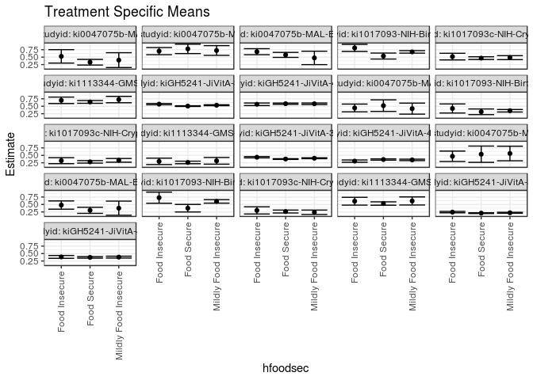

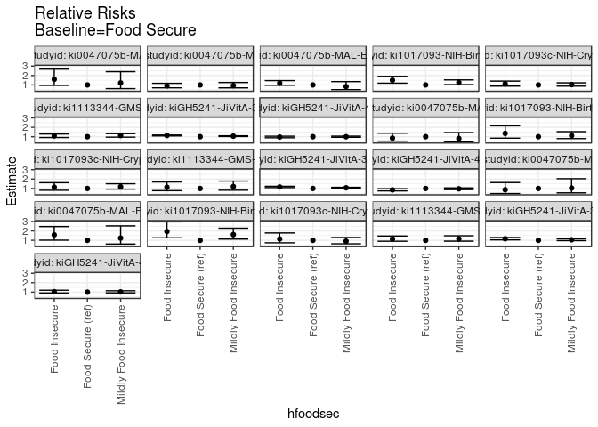

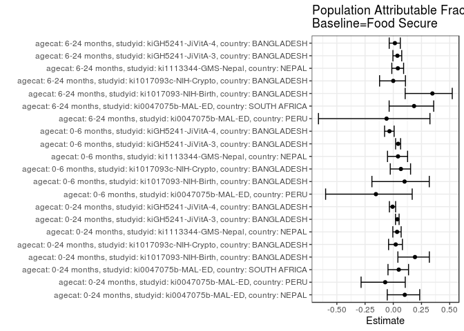

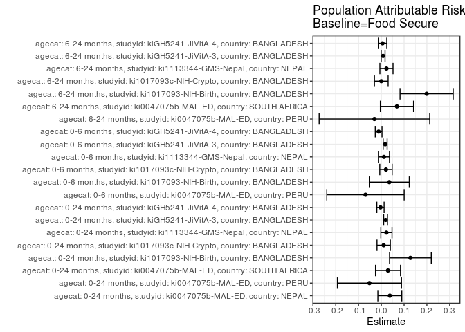

## Results Table

### Parameter: TSM

| agecat | studyid | country | intervention_level | baseline_level | estimate | ci_lower | ci_upper |
| --- | --- | --- | --- | --- | --- | --- | --- |
| 0-24 months | ki0047075b-MAL-ED | NEPAL | Food Secure | NA | 0.3297872 | 0.2343736 | 0.4252009 |
| 0-24 months | ki0047075b-MAL-ED | NEPAL | Mildly Food Insecure | NA | 0.4000000 | 0.1511078 | 0.6488922 |
| 0-24 months | ki0047075b-MAL-ED | NEPAL | Food Insecure | NA | 0.5263158 | 0.3009219 | 0.7517096 |
| 0-24 months | ki0047075b-MAL-ED | PERU | Food Secure | NA | 0.7777778 | 0.6202642 | 0.9352913 |
| 0-24 months | ki0047075b-MAL-ED | PERU | Mildly Food Insecure | NA | 0.7241379 | 0.5607440 | 0.8875319 |
| 0-24 months | ki0047075b-MAL-ED | PERU | Food Insecure | NA | 0.7017544 | 0.5824599 | 0.8210489 |
| 0-24 months | ki0047075b-MAL-ED | SOUTH AFRICA | Food Secure | NA | 0.5757576 | 0.4912643 | 0.6602508 |
| 0-24 months | ki0047075b-MAL-ED | SOUTH AFRICA | Mildly Food Insecure | NA | 0.4736842 | 0.2486892 | 0.6986792 |
| 0-24 months | ki0047075b-MAL-ED | SOUTH AFRICA | Food Insecure | NA | 0.6829268 | 0.5819918 | 0.7838619 |
| 0-24 months | ki1017093-NIH-Birth | BANGLADESH | Food Secure | NA | 0.5368421 | 0.4364916 | 0.6371926 |
| 0-24 months | ki1017093-NIH-Birth | BANGLADESH | Mildly Food Insecure | NA | 0.6768293 | 0.6354706 | 0.7181879 |
| 0-24 months | ki1017093-NIH-Birth | BANGLADESH | Food Insecure | NA | 0.8095238 | 0.6906725 | 0.9283752 |
| 0-24 months | ki1017093c-NIH-Crypto | BANGLADESH | Food Secure | NA | 0.4672215 | 0.4212219 | 0.5132212 |
| 0-24 months | ki1017093c-NIH-Crypto | BANGLADESH | Mildly Food Insecure | NA | 0.4832143 | 0.4165512 | 0.5498773 |
| 0-24 months | ki1017093c-NIH-Crypto | BANGLADESH | Food Insecure | NA | 0.5186522 | 0.4071304 | 0.6301740 |
| 0-24 months | ki1113344-GMS-Nepal | NEPAL | Food Secure | NA | 0.6453776 | 0.5987546 | 0.6920006 |
| 0-24 months | ki1113344-GMS-Nepal | NEPAL | Mildly Food Insecure | NA | 0.7245768 | 0.6174690 | 0.8316845 |
| 0-24 months | ki1113344-GMS-Nepal | NEPAL | Food Insecure | NA | 0.6991484 | 0.5905760 | 0.8077208 |
| 0-24 months | kiGH5241-JiVitA-3 | BANGLADESH | Food Secure | NA | 0.5045659 | 0.4923362 | 0.5167956 |
| 0-24 months | kiGH5241-JiVitA-3 | BANGLADESH | Mildly Food Insecure | NA | 0.5345492 | 0.5193258 | 0.5497727 |
| 0-24 months | kiGH5241-JiVitA-3 | BANGLADESH | Food Insecure | NA | 0.5704053 | 0.5487978 | 0.5920129 |
| 0-24 months | kiGH5241-JiVitA-4 | BANGLADESH | Food Secure | NA | 0.5850362 | 0.5628094 | 0.6072630 |
| 0-24 months | kiGH5241-JiVitA-4 | BANGLADESH | Mildly Food Insecure | NA | 0.5829138 | 0.5571530 | 0.6086745 |
| 0-24 months | kiGH5241-JiVitA-4 | BANGLADESH | Food Insecure | NA | 0.5662489 | 0.5235172 | 0.6089805 |
| 0-6 months | ki0047075b-MAL-ED | PERU | Food Secure | NA | 0.5207896 | 0.3259897 | 0.7155895 |
| 0-6 months | ki0047075b-MAL-ED | PERU | Mildly Food Insecure | NA | 0.4202976 | 0.2349075 | 0.6056877 |
| 0-6 months | ki0047075b-MAL-ED | PERU | Food Insecure | NA | 0.4422501 | 0.3115546 | 0.5729455 |
| 0-6 months | ki1017093-NIH-Birth | BANGLADESH | Food Secure | NA | 0.3147513 | 0.2200011 | 0.4095015 |
| 0-6 months | ki1017093-NIH-Birth | BANGLADESH | Mildly Food Insecure | NA | 0.3492107 | 0.3069993 | 0.3914220 |
| 0-6 months | ki1017093-NIH-Birth | BANGLADESH | Food Insecure | NA | 0.4250621 | 0.2729826 | 0.5771416 |
| 0-6 months | ki1017093c-NIH-Crypto | BANGLADESH | Food Secure | NA | 0.2816937 | 0.2401621 | 0.3232253 |
| 0-6 months | ki1017093c-NIH-Crypto | BANGLADESH | Mildly Food Insecure | NA | 0.3333754 | 0.2705737 | 0.3961772 |
| 0-6 months | ki1017093c-NIH-Crypto | BANGLADESH | Food Insecure | NA | 0.3220367 | 0.2212368 | 0.4228365 |
| 0-6 months | ki1113344-GMS-Nepal | NEPAL | Food Secure | NA | 0.2624702 | 0.2194655 | 0.3054749 |
| 0-6 months | ki1113344-GMS-Nepal | NEPAL | Mildly Food Insecure | NA | 0.3168528 | 0.2037318 | 0.4299739 |
| 0-6 months | ki1113344-GMS-Nepal | NEPAL | Food Insecure | NA | 0.2993725 | 0.1921788 | 0.4065662 |
| 0-6 months | kiGH5241-JiVitA-3 | BANGLADESH | Food Secure | NA | 0.3766336 | 0.3643782 | 0.3888889 |
| 0-6 months | kiGH5241-JiVitA-3 | BANGLADESH | Mildly Food Insecure | NA | 0.4036942 | 0.3891173 | 0.4182711 |
| 0-6 months | kiGH5241-JiVitA-3 | BANGLADESH | Food Insecure | NA | 0.4370552 | 0.4155714 | 0.4585391 |
| 0-6 months | kiGH5241-JiVitA-4 | BANGLADESH | Food Secure | NA | 0.3601731 | 0.3389387 | 0.3814074 |
| 0-6 months | kiGH5241-JiVitA-4 | BANGLADESH | Mildly Food Insecure | NA | 0.3477938 | 0.3226179 | 0.3729697 |
| 0-6 months | kiGH5241-JiVitA-4 | BANGLADESH | Food Insecure | NA | 0.3067458 | 0.2687786 | 0.3447130 |
| 6-24 months | ki0047075b-MAL-ED | PERU | Food Secure | NA | 0.5384615 | 0.2652198 | 0.8117033 |
| 6-24 months | ki0047075b-MAL-ED | PERU | Mildly Food Insecure | NA | 0.5625000 | 0.3174088 | 0.8075912 |
| 6-24 months | ki0047075b-MAL-ED | PERU | Food Insecure | NA | 0.4687500 | 0.2944158 | 0.6430842 |
| 6-24 months | ki0047075b-MAL-ED | SOUTH AFRICA | Food Secure | NA | 0.3037975 | 0.2020328 | 0.4055622 |
| 6-24 months | ki0047075b-MAL-ED | SOUTH AFRICA | Mildly Food Insecure | NA | 0.3750000 | 0.1369619 | 0.6130381 |
| 6-24 months | ki0047075b-MAL-ED | SOUTH AFRICA | Food Insecure | NA | 0.4800000 | 0.3410405 | 0.6189595 |
| 6-24 months | ki1017093-NIH-Birth | BANGLADESH | Food Secure | NA | 0.3750000 | 0.2480186 | 0.5019814 |
| 6-24 months | ki1017093-NIH-Birth | BANGLADESH | Mildly Food Insecure | NA | 0.6029963 | 0.5442233 | 0.6617692 |
| 6-24 months | ki1017093-NIH-Birth | BANGLADESH | Food Insecure | NA | 0.7272727 | 0.5409010 | 0.9136444 |
| 6-24 months | ki1017093c-NIH-Crypto | BANGLADESH | Food Secure | NA | 0.2629104 | 0.2142951 | 0.3115257 |
| 6-24 months | ki1017093c-NIH-Crypto | BANGLADESH | Mildly Food Insecure | NA | 0.2378999 | 0.1646364 | 0.3111635 |
| 6-24 months | ki1017093c-NIH-Crypto | BANGLADESH | Food Insecure | NA | 0.3009971 | 0.1804167 | 0.4215775 |
| 6-24 months | ki1113344-GMS-Nepal | NEPAL | Food Secure | NA | 0.5316552 | 0.4753630 | 0.5879473 |
| 6-24 months | ki1113344-GMS-Nepal | NEPAL | Mildly Food Insecure | NA | 0.6177130 | 0.4818494 | 0.7535766 |
| 6-24 months | ki1113344-GMS-Nepal | NEPAL | Food Insecure | NA | 0.6092203 | 0.4778205 | 0.7406202 |
| 6-24 months | kiGH5241-JiVitA-3 | BANGLADESH | Food Secure | NA | 0.2092736 | 0.1970545 | 0.2214928 |
| 6-24 months | kiGH5241-JiVitA-3 | BANGLADESH | Mildly Food Insecure | NA | 0.2211044 | 0.2046428 | 0.2375660 |
| 6-24 months | kiGH5241-JiVitA-3 | BANGLADESH | Food Insecure | NA | 0.2438096 | 0.2199704 | 0.2676487 |
| 6-24 months | kiGH5241-JiVitA-4 | BANGLADESH | Food Secure | NA | 0.3719161 | 0.3460008 | 0.3978313 |
| 6-24 months | kiGH5241-JiVitA-4 | BANGLADESH | Mildly Food Insecure | NA | 0.3809853 | 0.3497362 | 0.4122344 |
| 6-24 months | kiGH5241-JiVitA-4 | BANGLADESH | Food Insecure | NA | 0.3883248 | 0.3403488 | 0.4363009 |

### Parameter: E(Y)

| agecat | studyid | country | intervention_level | baseline_level | estimate | ci_lower | ci_upper |
| --- | --- | --- | --- | --- | --- | --- | --- |
| 0-24 months | ki0047075b-MAL-ED | NEPAL | NA | NA | 0.3671875 | 0.2833521 | 0.4510229 |
| 0-24 months | ki0047075b-MAL-ED | PERU | NA | NA | 0.7256637 | 0.6430317 | 0.8082957 |
| 0-24 months | ki0047075b-MAL-ED | SOUTH AFRICA | NA | NA | 0.6051502 | 0.5422501 | 0.6680504 |
| 0-24 months | ki1017093-NIH-Birth | BANGLADESH | NA | NA | 0.6645469 | 0.6276196 | 0.7014742 |
| 0-24 months | ki1017093c-NIH-Crypto | BANGLADESH | NA | NA | 0.4775726 | 0.4419904 | 0.5131548 |
| 0-24 months | ki1113344-GMS-Nepal | NEPAL | NA | NA | 0.6678082 | 0.6295756 | 0.7060408 |
| 0-24 months | kiGH5241-JiVitA-3 | BANGLADESH | NA | NA | 0.5232725 | 0.5136886 | 0.5328564 |
| 0-24 months | kiGH5241-JiVitA-4 | BANGLADESH | NA | NA | 0.5813264 | 0.5653125 | 0.5973403 |
| 0-6 months | ki0047075b-MAL-ED | PERU | NA | NA | 0.4513274 | 0.3591676 | 0.5434872 |
| 0-6 months | ki1017093-NIH-Birth | BANGLADESH | NA | NA | 0.3497615 | 0.3124631 | 0.3870600 |
| 0-6 months | ki1017093c-NIH-Crypto | BANGLADESH | NA | NA | 0.3021108 | 0.2694011 | 0.3348205 |
| 0-6 months | ki1113344-GMS-Nepal | NEPAL | NA | NA | 0.2739726 | 0.2377697 | 0.3101755 |
| 0-6 months | kiGH5241-JiVitA-3 | BANGLADESH | NA | NA | 0.3935789 | 0.3847652 | 0.4023927 |
| 0-6 months | kiGH5241-JiVitA-4 | BANGLADESH | NA | NA | 0.3483896 | 0.3331073 | 0.3636720 |
| 6-24 months | ki0047075b-MAL-ED | PERU | NA | NA | 0.5081967 | 0.3816986 | 0.6346949 |
| 6-24 months | ki0047075b-MAL-ED | SOUTH AFRICA | NA | NA | 0.3724138 | 0.2934521 | 0.4513755 |
| 6-24 months | ki1017093-NIH-Birth | BANGLADESH | NA | NA | 0.5739130 | 0.5216565 | 0.6261696 |
| 6-24 months | ki1017093c-NIH-Crypto | BANGLADESH | NA | NA | 0.2628458 | 0.2244546 | 0.3012371 |
| 6-24 months | ki1113344-GMS-Nepal | NEPAL | NA | NA | 0.5542169 | 0.5063374 | 0.6020964 |
| 6-24 months | kiGH5241-JiVitA-3 | BANGLADESH | NA | NA | 0.2172338 | 0.2078312 | 0.2266365 |
| 6-24 months | kiGH5241-JiVitA-4 | BANGLADESH | NA | NA | 0.3773167 | 0.3586399 | 0.3959936 |

### Parameter: RR

| agecat | studyid | country | intervention_level | baseline_level | estimate | ci_lower | ci_upper |
| --- | --- | --- | --- | --- | --- | --- | --- |
| 0-24 months | ki0047075b-MAL-ED | NEPAL | Food Secure | Food Secure | 1.0000000 | 1.0000000 | 1.0000000 |
| 0-24 months | ki0047075b-MAL-ED | NEPAL | Mildly Food Insecure | Food Secure | 1.2129032 | 0.6106769 | 2.4090222 |
| 0-24 months | ki0047075b-MAL-ED | NEPAL | Food Insecure | Food Secure | 1.5959253 | 0.9518332 | 2.6758654 |
| 0-24 months | ki0047075b-MAL-ED | PERU | Food Secure | Food Secure | 1.0000000 | 1.0000000 | 1.0000000 |
| 0-24 months | ki0047075b-MAL-ED | PERU | Mildly Food Insecure | Food Secure | 0.9310345 | 0.6875281 | 1.2607852 |
| 0-24 months | ki0047075b-MAL-ED | PERU | Food Insecure | Food Secure | 0.9022556 | 0.6926259 | 1.1753317 |
| 0-24 months | ki0047075b-MAL-ED | SOUTH AFRICA | Food Secure | Food Secure | 1.0000000 | 1.0000000 | 1.0000000 |
| 0-24 months | ki0047075b-MAL-ED | SOUTH AFRICA | Mildly Food Insecure | Food Secure | 0.8227147 | 0.5004294 | 1.3525572 |
| 0-24 months | ki0047075b-MAL-ED | SOUTH AFRICA | Food Insecure | Food Secure | 1.1861361 | 0.9631193 | 1.4607939 |
| 0-24 months | ki1017093-NIH-Birth | BANGLADESH | Food Secure | Food Secure | 1.0000000 | 1.0000000 | 1.0000000 |
| 0-24 months | ki1017093-NIH-Birth | BANGLADESH | Mildly Food Insecure | Food Secure | 1.2607604 | 1.0356748 | 1.5347643 |
| 0-24 months | ki1017093-NIH-Birth | BANGLADESH | Food Insecure | Food Secure | 1.5079365 | 1.1889272 | 1.9125414 |
| 0-24 months | ki1017093c-NIH-Crypto | BANGLADESH | Food Secure | Food Secure | 1.0000000 | 1.0000000 | 1.0000000 |
| 0-24 months | ki1017093c-NIH-Crypto | BANGLADESH | Mildly Food Insecure | Food Secure | 1.0342295 | 0.8738628 | 1.2240257 |
| 0-24 months | ki1017093c-NIH-Crypto | BANGLADESH | Food Insecure | Food Secure | 1.1100776 | 0.8766324 | 1.4056887 |
| 0-24 months | ki1113344-GMS-Nepal | NEPAL | Food Secure | Food Secure | 1.0000000 | 1.0000000 | 1.0000000 |
| 0-24 months | ki1113344-GMS-Nepal | NEPAL | Mildly Food Insecure | Food Secure | 1.1227176 | 0.9522655 | 1.3236801 |
| 0-24 months | ki1113344-GMS-Nepal | NEPAL | Food Insecure | Food Secure | 1.0833168 | 0.9126340 | 1.2859210 |
| 0-24 months | kiGH5241-JiVitA-3 | BANGLADESH | Food Secure | Food Secure | 1.0000000 | 1.0000000 | 1.0000000 |
| 0-24 months | kiGH5241-JiVitA-3 | BANGLADESH | Mildly Food Insecure | Food Secure | 1.0594239 | 1.0238785 | 1.0962033 |
| 0-24 months | kiGH5241-JiVitA-3 | BANGLADESH | Food Insecure | Food Secure | 1.1304872 | 1.0839308 | 1.1790433 |
| 0-24 months | kiGH5241-JiVitA-4 | BANGLADESH | Food Secure | Food Secure | 1.0000000 | 1.0000000 | 1.0000000 |
| 0-24 months | kiGH5241-JiVitA-4 | BANGLADESH | Mildly Food Insecure | Food Secure | 0.9963721 | 0.9395983 | 1.0565764 |
| 0-24 months | kiGH5241-JiVitA-4 | BANGLADESH | Food Insecure | Food Secure | 0.9678869 | 0.8891539 | 1.0535915 |
| 0-6 months | ki0047075b-MAL-ED | PERU | Food Secure | Food Secure | 1.0000000 | 1.0000000 | 1.0000000 |
| 0-6 months | ki0047075b-MAL-ED | PERU | Mildly Food Insecure | Food Secure | 0.8070391 | 0.4531452 | 1.4373144 |
| 0-6 months | ki0047075b-MAL-ED | PERU | Food Insecure | Food Secure | 0.8491914 | 0.5274450 | 1.3672061 |
| 0-6 months | ki1017093-NIH-Birth | BANGLADESH | Food Secure | Food Secure | 1.0000000 | 1.0000000 | 1.0000000 |
| 0-6 months | ki1017093-NIH-Birth | BANGLADESH | Mildly Food Insecure | Food Secure | 1.1094812 | 0.8020138 | 1.5348221 |
| 0-6 months | ki1017093-NIH-Birth | BANGLADESH | Food Insecure | Food Secure | 1.3504697 | 0.8461018 | 2.1554952 |
| 0-6 months | ki1017093c-NIH-Crypto | BANGLADESH | Food Secure | Food Secure | 1.0000000 | 1.0000000 | 1.0000000 |
| 0-6 months | ki1017093c-NIH-Crypto | BANGLADESH | Mildly Food Insecure | Food Secure | 1.1834678 | 0.9317798 | 1.5031404 |
| 0-6 months | ki1017093c-NIH-Crypto | BANGLADESH | Food Insecure | Food Secure | 1.1432157 | 0.8086285 | 1.6162454 |
| 0-6 months | ki1113344-GMS-Nepal | NEPAL | Food Secure | Food Secure | 1.0000000 | 1.0000000 | 1.0000000 |
| 0-6 months | ki1113344-GMS-Nepal | NEPAL | Mildly Food Insecure | Food Secure | 1.2071954 | 0.8148129 | 1.7885340 |
| 0-6 months | ki1113344-GMS-Nepal | NEPAL | Food Insecure | Food Secure | 1.1405962 | 0.7693006 | 1.6910941 |
| 0-6 months | kiGH5241-JiVitA-3 | BANGLADESH | Food Secure | Food Secure | 1.0000000 | 1.0000000 | 1.0000000 |
| 0-6 months | kiGH5241-JiVitA-3 | BANGLADESH | Mildly Food Insecure | Food Secure | 1.0718487 | 1.0226993 | 1.1233602 |
| 0-6 months | kiGH5241-JiVitA-3 | BANGLADESH | Food Insecure | Food Secure | 1.1604257 | 1.0957924 | 1.2288713 |
| 0-6 months | kiGH5241-JiVitA-4 | BANGLADESH | Food Secure | Food Secure | 1.0000000 | 1.0000000 | 1.0000000 |
| 0-6 months | kiGH5241-JiVitA-4 | BANGLADESH | Mildly Food Insecure | Food Secure | 0.9656297 | 0.8806033 | 1.0588658 |
| 0-6 months | kiGH5241-JiVitA-4 | BANGLADESH | Food Insecure | Food Secure | 0.8516622 | 0.7422275 | 0.9772321 |
| 6-24 months | ki0047075b-MAL-ED | PERU | Food Secure | Food Secure | 1.0000000 | 1.0000000 | 1.0000000 |
| 6-24 months | ki0047075b-MAL-ED | PERU | Mildly Food Insecure | Food Secure | 1.0446429 | 0.5351702 | 2.0391245 |
| 6-24 months | ki0047075b-MAL-ED | PERU | Food Insecure | Food Secure | 0.8705357 | 0.4640367 | 1.6331303 |
| 6-24 months | ki0047075b-MAL-ED | SOUTH AFRICA | Food Secure | Food Secure | 1.0000000 | 1.0000000 | 1.0000000 |
| 6-24 months | ki0047075b-MAL-ED | SOUTH AFRICA | Mildly Food Insecure | Food Secure | 1.2343750 | 0.6021990 | 2.5301963 |
| 6-24 months | ki0047075b-MAL-ED | SOUTH AFRICA | Food Insecure | Food Secure | 1.5800000 | 1.0147938 | 2.4600071 |
| 6-24 months | ki1017093-NIH-Birth | BANGLADESH | Food Secure | Food Secure | 1.0000000 | 1.0000000 | 1.0000000 |
| 6-24 months | ki1017093-NIH-Birth | BANGLADESH | Mildly Food Insecure | Food Secure | 1.6079900 | 1.1304540 | 2.2872508 |
| 6-24 months | ki1017093-NIH-Birth | BANGLADESH | Food Insecure | Food Secure | 1.9393939 | 1.2683556 | 2.9654529 |
| 6-24 months | ki1017093c-NIH-Crypto | BANGLADESH | Food Secure | Food Secure | 1.0000000 | 1.0000000 | 1.0000000 |
| 6-24 months | ki1017093c-NIH-Crypto | BANGLADESH | Mildly Food Insecure | Food Secure | 0.9048709 | 0.6318915 | 1.2957782 |
| 6-24 months | ki1017093c-NIH-Crypto | BANGLADESH | Food Insecure | Food Secure | 1.1448658 | 0.7365087 | 1.7796364 |
| 6-24 months | ki1113344-GMS-Nepal | NEPAL | Food Secure | Food Secure | 1.0000000 | 1.0000000 | 1.0000000 |
| 6-24 months | ki1113344-GMS-Nepal | NEPAL | Mildly Food Insecure | Food Secure | 1.1618679 | 0.9102184 | 1.4830913 |
| 6-24 months | ki1113344-GMS-Nepal | NEPAL | Food Insecure | Food Secure | 1.1458938 | 0.9009369 | 1.4574523 |
| 6-24 months | kiGH5241-JiVitA-3 | BANGLADESH | Food Secure | Food Secure | 1.0000000 | 1.0000000 | 1.0000000 |
| 6-24 months | kiGH5241-JiVitA-3 | BANGLADESH | Mildly Food Insecure | Food Secure | 1.0565326 | 0.9647214 | 1.1570813 |
| 6-24 months | kiGH5241-JiVitA-3 | BANGLADESH | Food Insecure | Food Secure | 1.1650277 | 1.0466751 | 1.2967630 |
| 6-24 months | kiGH5241-JiVitA-4 | BANGLADESH | Food Secure | Food Secure | 1.0000000 | 1.0000000 | 1.0000000 |
| 6-24 months | kiGH5241-JiVitA-4 | BANGLADESH | Mildly Food Insecure | Food Secure | 1.0243851 | 0.9192751 | 1.1415135 |
| 6-24 months | kiGH5241-JiVitA-4 | BANGLADESH | Food Insecure | Food Secure | 1.0441195 | 0.9075803 | 1.2012002 |

### Parameter: PAR

| agecat | studyid | country | intervention_level | baseline_level | estimate | ci_lower | ci_upper |
| --- | --- | --- | --- | --- | --- | --- | --- |
| 0-24 months | ki0047075b-MAL-ED | NEPAL | Food Secure | NA | 0.0374003 | -0.0151449 | 0.0899454 |
| 0-24 months | ki0047075b-MAL-ED | PERU | Food Secure | NA | -0.0521141 | -0.1927633 | 0.0885352 |
| 0-24 months | ki0047075b-MAL-ED | SOUTH AFRICA | Food Secure | NA | 0.0293926 | -0.0254397 | 0.0842250 |
| 0-24 months | ki1017093-NIH-Birth | BANGLADESH | Food Secure | NA | 0.1277048 | 0.0360971 | 0.2193125 |
| 0-24 months | ki1017093c-NIH-Crypto | BANGLADESH | Food Secure | NA | 0.0103510 | -0.0189445 | 0.0396466 |
| 0-24 months | ki1113344-GMS-Nepal | NEPAL | Food Secure | NA | 0.0224307 | -0.0020946 | 0.0469559 |
| 0-24 months | kiGH5241-JiVitA-3 | BANGLADESH | Food Secure | NA | 0.0187066 | 0.0103847 | 0.0270286 |
| 0-24 months | kiGH5241-JiVitA-4 | BANGLADESH | Food Secure | NA | -0.0037098 | -0.0196888 | 0.0122692 |
| 0-6 months | ki0047075b-MAL-ED | PERU | Food Secure | NA | -0.0694622 | -0.2392584 | 0.1003340 |
| 0-6 months | ki1017093-NIH-Birth | BANGLADESH | Food Secure | NA | 0.0350102 | -0.0527154 | 0.1227358 |
| 0-6 months | ki1017093c-NIH-Crypto | BANGLADESH | Food Secure | NA | 0.0204171 | -0.0067321 | 0.0475663 |
| 0-6 months | ki1113344-GMS-Nepal | NEPAL | Food Secure | NA | 0.0115024 | -0.0128457 | 0.0358506 |
| 0-6 months | kiGH5241-JiVitA-3 | BANGLADESH | Food Secure | NA | 0.0169454 | 0.0082036 | 0.0256872 |
| 0-6 months | kiGH5241-JiVitA-4 | BANGLADESH | Food Secure | NA | -0.0117834 | -0.0265722 | 0.0030053 |
| 6-24 months | ki0047075b-MAL-ED | PERU | Food Secure | NA | -0.0302648 | -0.2728345 | 0.2123049 |
| 6-24 months | ki0047075b-MAL-ED | SOUTH AFRICA | Food Secure | NA | 0.0686163 | -0.0042292 | 0.1414619 |
| 6-24 months | ki1017093-NIH-Birth | BANGLADESH | Food Secure | NA | 0.1989130 | 0.0822062 | 0.3156198 |
| 6-24 months | ki1017093c-NIH-Crypto | BANGLADESH | Food Secure | NA | -0.0000645 | -0.0301235 | 0.0299944 |
| 6-24 months | ki1113344-GMS-Nepal | NEPAL | Food Secure | NA | 0.0225617 | -0.0062800 | 0.0514034 |
| 6-24 months | kiGH5241-JiVitA-3 | BANGLADESH | Food Secure | NA | 0.0079602 | -0.0005348 | 0.0164552 |
| 6-24 months | kiGH5241-JiVitA-4 | BANGLADESH | Food Secure | NA | 0.0054007 | -0.0131647 | 0.0239661 |

### Parameter: PAF

| agecat | studyid | country | intervention_level | baseline_level | estimate | ci_lower | ci_upper |
| --- | --- | --- | --- | --- | --- | --- | --- |
| 0-24 months | ki0047075b-MAL-ED | NEPAL | Food Secure | NA | 0.1018560 | -0.0533699 | 0.2342077 |
| 0-24 months | ki0047075b-MAL-ED | PERU | Food Secure | NA | -0.0718157 | -0.2852318 | 0.1061621 |
| 0-24 months | ki0047075b-MAL-ED | SOUTH AFRICA | Food Secure | NA | 0.0485708 | -0.0467897 | 0.1352442 |
| 0-24 months | ki1017093-NIH-Birth | BANGLADESH | Food Secure | NA | 0.1921682 | 0.0407818 | 0.3196624 |
| 0-24 months | ki1017093c-NIH-Crypto | BANGLADESH | Food Secure | NA | 0.0216742 | -0.0416481 | 0.0811472 |
| 0-24 months | ki1113344-GMS-Nepal | NEPAL | Food Secure | NA | 0.0335885 | -0.0040128 | 0.0697816 |
| 0-24 months | kiGH5241-JiVitA-3 | BANGLADESH | Food Secure | NA | 0.0357493 | 0.0197482 | 0.0514891 |
| 0-24 months | kiGH5241-JiVitA-4 | BANGLADESH | Food Secure | NA | -0.0063816 | -0.0342544 | 0.0207400 |
| 0-6 months | ki0047075b-MAL-ED | PERU | Food Secure | NA | -0.1539064 | -0.5996489 | 0.1676298 |
| 0-6 months | ki1017093-NIH-Birth | BANGLADESH | Food Secure | NA | 0.1000974 | -0.1892221 | 0.3190299 |
| 0-6 months | ki1017093c-NIH-Crypto | BANGLADESH | Food Secure | NA | 0.0675815 | -0.0267120 | 0.1532151 |
| 0-6 months | ki1113344-GMS-Nepal | NEPAL | Food Secure | NA | 0.0419838 | -0.0511427 | 0.1268597 |
| 0-6 months | kiGH5241-JiVitA-3 | BANGLADESH | Food Secure | NA | 0.0430546 | 0.0205874 | 0.0650065 |
| 0-6 months | kiGH5241-JiVitA-4 | BANGLADESH | Food Secure | NA | -0.0338226 | -0.0771866 | 0.0077958 |
| 6-24 months | ki0047075b-MAL-ED | PERU | Food Secure | NA | -0.0595534 | -0.6629489 | 0.3249021 |
| 6-24 months | ki0047075b-MAL-ED | SOUTH AFRICA | Food Secure | NA | 0.1842475 | -0.0366419 | 0.3580695 |
| 6-24 months | ki1017093-NIH-Birth | BANGLADESH | Food Secure | NA | 0.3465909 | 0.1055065 | 0.5226981 |
| 6-24 months | ki1017093c-NIH-Crypto | BANGLADESH | Food Secure | NA | -0.0002455 | -0.1213992 | 0.1078189 |
| 6-24 months | ki1113344-GMS-Nepal | NEPAL | Food Secure | NA | 0.0407092 | -0.0129537 | 0.0915292 |
| 6-24 months | kiGH5241-JiVitA-3 | BANGLADESH | Food Secure | NA | 0.0366434 | -0.0031832 | 0.0748889 |
| 6-24 months | kiGH5241-JiVitA-4 | BANGLADESH | Food Secure | NA | 0.0143134 | -0.0361210 | 0.0622927 |